# ASDIA Projet 1

# Partie 1 : Apprentissage supervisé pour la classification

L’objet de cette partie est de démontrer le résultat suivant.

**Théorème.** *Soit $q({\bf x})$ une fonction arbitraire à valeur dans $[0,1]$ et*
$$q_{\rm opt}({\bf x}) = p(y = 1|{\bf x}) \, , \quad \forall {\bf x}.$$
*Alors, nous avons*
$$\mathbb{E}[L(q({\bf x}), y )] \geq \mathbb{E}[L(q_{\rm opt}({\bf x}), y )] .$$

- **Conditionnement** :

$$\mathbb{E}[L(q({\bf x}), y)]=\int\mathbb{E}[L(q({\bf x}), y)| x]p({\bf x})dx$$
Comme $p({\bf x }) \in [0, 1] (>0)$, pour minimiser l’espérance $\mathbb{E}[L(q({\bf x}), y )]$ il suffit de minimiser l’espérance conditionnelle $\mathbb{E}[L(q({\bf x}), y ) | {\bf x}]$ pour tout ${\bf x}$.

- **Entropie croisée** :

$$\begin{align}
\mathbb{KL}(p \| p^\prime) &= p(y = 0) \log \frac{p(y = 0)}{p \prime y = 0} + p(y =1) \log \frac{p(y=1)}{p \prime (y = 1)}\\
&= h(p, p\prime) + p(y=0)\log p(y=0) + p(y=1) \log p(y=1)\\
&= h(p, p \prime) - h(p)
\end{align}$$

Comme la divergence de Kulback-Leibler est positive, on obtient bien l’inégalité suivante :
$$h(p, p') \geq h(p)$$

- **Entropie croisée et log-loss** : On appelle $q_{.}({\bf x})$ la loi de Bernoulli de paramètre $q({\bf x})$. Montrons que:

$$\mathbb{E}[L(q({\bf x}), y ) | {\bf x}] = h(p_{\sf Y}(.|{\bf x}), q_{.}({\bf x})) .$$

Démonstration:

$$\begin{align}
\mathbb{E}[L(q({\bf x}, y)|{\bf x})] &= \mathbb{E}[-y \log q({\bf x}) - (1-y)\log (1-q({\bf x}))|{\bf x}]\\
&= -\log q({\bf x}) \mathbb{E[y]}-\log(1-q({\bf x}))(1 - \mathbb{E}[y])\\
&=-p(y=1|{\bf x}) \log q({\bf x}) - (1 - p(y=1|{\bf x}))\log (1-q({\bf x}))\\
&= -p(y=0|{\bf x}) \log (1-q({\bf x})) - p(y=1|{\bf x})\log (q({\bf x}))\\
&= h(p_Y(.|{\bf x}), q_.({\bf x}))
\end{align}$$

- Démontrer le théorème.

avec $q_.({\bf x})$ la loi de Bernouilli de paramètre $q({\bf x})$. Or, on peut remarquer que $p_Y(.|x)$ suit la loi de Bernouilli de paramètre $q_{opt}$. Ainsi, on peut poser l’égalité suivante:

$$\begin{align}
\mathbb{E}[L(q_{opt}({\bf x}), y)|{\bf x}] &= h(p_Y(.|x), p_Y(.|x))\\
&=h(p_Y(.|x))
\end{align}$$

Or, on a montré l’inégalité suivante:$h(p, p') \geq h(p)$.

Ainsi, $h(p_Y(.|{\bf x}), q_.({\bf x})) \geq h(p_Y(.|x))$.

Ainsi, en multipliant les deux membres de l’inégalité ci-dessus, et en intégrant sur le domaine de définition de x, on obtient le résultat voulu :
$$\mathbb{E}(L(q({\bf x}), y))\geq \mathbb{E}(L(q_{opt}({\bf x}), y))$$

*Démontrer que le minimum de la fonction de perte correspond au maximum de la vraisemblance pour ce modèle.

# Partie 2 : Reconnaissance de chiffres manuscrits (2 et 7)

## Lecture des données

- Lire les données MNIST. Il y a 4 ensembles de variables.

```r
  library(keras)
  library(magrittr)
  mnist <- dataset_mnist()
  x_train <- mnist$train$x
  y_train <- mnist$train$y
  x_test <- mnist$test$x
  y_test <- mnist$test$y
```

- Filtrer les données correspondant aux chiffres $2$ et $7$. Commenter et compléter le code suivant. Exécuter le code en changeant l’option de chunck.

```r
# On conserve les 2 et les 7 uniquement
  boo_train <- y_train == 2 | y_train == 7
  x_train <- mnist$train$x[boo_train,,]
  y_train <- mnist$train$y[boo_train]

# Idem pour le set de test
  boo_test <- y_test == 2 | y_test == 7
  x_test <- mnist$test$x[boo_test,,]
  y_test <- mnist$test$y[boo_test]
```

- Utiliser la fonction `image()` pour visualiser le premier chiffre test de la base de données réduite. C’est un 7.

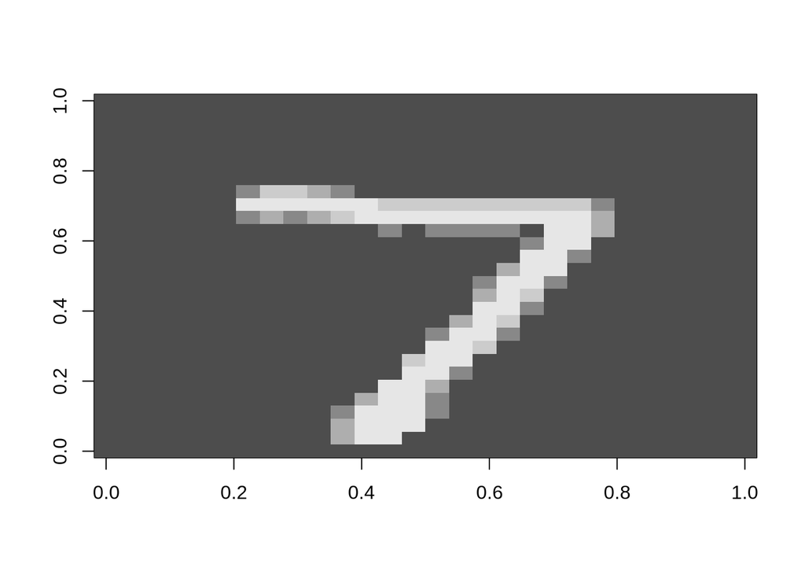

```r
  image(t(x_test[1, 28:1,]), col = grey.colors(5))
```

- Les images de dimension 28x28 doivent être converties en vecteurs de longueur 784 ($= 28 \times 28$). Cela peut se faire de plusieurs manières. En particulier, la fonction `array_reshape()` de keras est très utile pour cela.

```r
# reshape
  x_train <- array_reshape(x_train, c(nrow(x_train), 784))
  x_test <- array_reshape(x_test, c(nrow(x_test), 784))
```

- Normaliser les données pour obtenir des valeurs réelles (flottants) entre 0 et 1 en divisant les valeurs présentes par 255. Utiliser la fonction `image()` pour visualiser le premier chiffre test de la base de données réduite dans cette nouvelle représentation.

```r
# rescale
  x_train <- x_train/255
  x_test <- x_test/255

# le symbol %>% est similaire au 'pipe' d'unix (library(magrittr))
  dim(x_test)
```

```
## [1] 2060  784
```

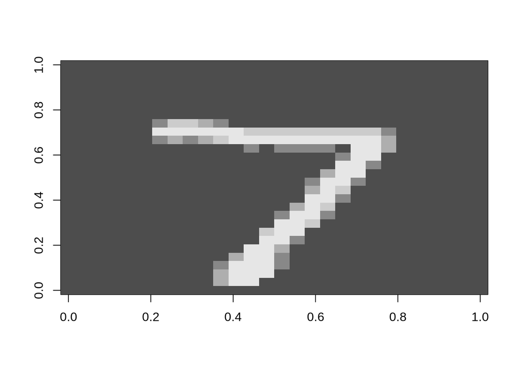

```r
  x_test[1,] %>% matrix(nrow = 28) %>% .[,28:1] %>% image(col = grey.colors(5))
```

- Les données de classe sont des entiers 2,7. Convertir ces données en variables booléennes ou binaires. La valeur 1 ou `TRUE` correspondra à un 7.

```r
  y_train <- y_train == 7
  y_test <-  y_test == 7
```

## Ajuster un réseau de neurone avec keras

- Construire un réseau de neurones à deux couches cachées à l’aide de la fonction `keras_model_sequential()`, en faisant varier les paramètres des couches comme ci-dessous. Définir les termes apparaissant dans la construction du modèle.
- Commenter et compléter le code suivant.

```r
  model <- keras_model_sequential()
  model %>%
    # Initialisation de la première couche avec fonctoin d'activation "relu" et 256 neurones.
    layer_dense(units = 256, activation = 'relu', input_shape = 784) %>%
    # On associe aléatoirement la valeur 0 à 50% des imahes d'entrée pour éviter l'over fitting.
    layer_dropout(rate = 0.5) %>%
    # Initialisation de la deuxième couche avec 128 neurones.
    layer_dense(units = 128, activation = 'relu') %>%
    layer_dropout(rate = 0.5) %>%
    # Initialisation de dernière couche
    layer_dense(units = 1, activation = 'sigmoid')
```

- Donner un tableau de correspondance entre les notions mathématiques introduites dans la section précédente et les termes apparaissant dans la construction du modèle.

```r
terme <- c("units = 256", "input_shape")
definition <- c("Dimension de la première couche cachée (W_2)", "Dimension des observations")
data.frame(terme, definition)
```

| terme | definition |
| --- | --- |
| units = 256 | Dimension de la première couche cachée (W_2) |
| input_shape | Dimension des observations |

- Compiler le modèle en précisant la fonction de perte (binary) et demander de visualiser le taux de bonne classification (accuracy). Le choix de l’optimiseur est spécifié.

```r
# Configuration du modèle pour l'entraînement
  model %>% compile(
    loss = 'binary_crossentropy',
    optimizer = optimizer_rmsprop(lr = 0.001, rho = 0.9, decay = 0),
    metrics = c('accuracy')
)
```

- Donner un tableau de correspondance entre les notions mathématiques introduites dans la section précédente et les termes apparaissant dans la compilation du modèle.

```r
terme <- c("loss", "optimizer", "lr", "rho", "decay", "accuracy")
definition <- c("Fonction de perte","Méthode de gradient stochastique","Taux d'apprentissage (pas dans la descente de gradient)","Facteur de décroissance moyenne du gradient","Baisse du taux d'apprentissage à chaque itération","Précision utilisée pour mesurer la pertinence du modèle")
data.frame(terme, definition)
```

| terme | definition |
| --- | --- |
| loss | Fonction de perte |
| optimizer | Méthode de gradient stochastique |
| lr | Taux d'apprentissage (pas dans la descente de gradient) |
| rho | Facteur de décroissance moyenne du gradient |
| decay | Baisse du taux d'apprentissage à chaque itération |
| accuracy | Précision utilisée pour mesurer la pertinence du modèle |

- Allons-y Alonso, pour ajuster le réseau (apprentissage)

```r
# A pprentissage : on entraîne le modèle
  history <- model %>% fit(
                        x_train,
                        y_train,
                        epochs = 20,
                        batch_size = 128,
                        validation_data = list(x_test, y_test)
)
```

- Donner un tableau de correspondance entre les notions mathématiques introduites dans la section précédente et les termes apparaissant dans l’apprentissage du modèle.

```r
terme <- c("x_train", "y_train", "epochs", "batch_size", "validation_data")
definition <- c("Ensemble des images (observations)","Sortie attendue","Nombre d'entraînements du modèle", "Nombre d'images utilisées par le réseau à chaque itération", "Données permettant d'évaluer le modèle")
data.frame(terme, definition)
```

| terme | definition |
| --- | --- |
| x_train | Ensemble des images (observations) |
| y_train | Sortie attendue |
| epochs | Nombre d'entraînements du modèle |
| batch_size | Nombre d'images utilisées par le réseau à chaque itération |
| validation_data | Données permettant d'évaluer le modèle |

- Quelle est signification des courbes `loss` et `val_loss` que l’on voit tracées?

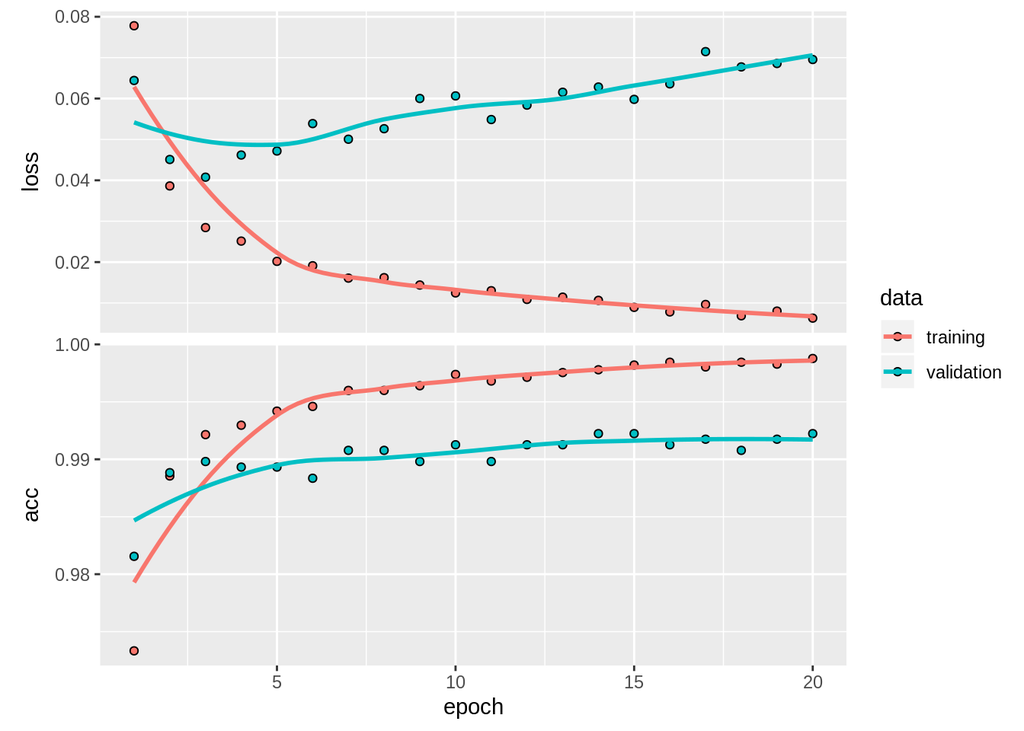

```r
plot(history)
```

Les coubes “loss” et “val_loss” représentent respectivement les pertes du modèle pour les données d’entraînement (x_train, y_train) et pour les données de tests (x_test, y_test).

- Evaluer le modèle sur les données de test (erreur de classification et perte log loss)

```r
model %>% evaluate(x_test, y_test)
```

```
## $loss
## [1] 0.06954271
##
## $acc
## [1] 0.992233
```

- Donner une matrice de confusion pour les classements effectués par le modèle sur le jeu test

```r
# help(table)
pred_class <- model %>% predict_classes(x_test)
table(predicted = pred_class, observed = mnist$test$y[boo_test])
```

```
##          observed
## predicted    2    7
##         0 1027   11
##         1    5 1017
```

- Montrer deux chiffres manuscrits que la machine n’a pas réussi à classer correctement. Donner la liste des mal classés et les probabilités de classement pour chacune des erreurs.

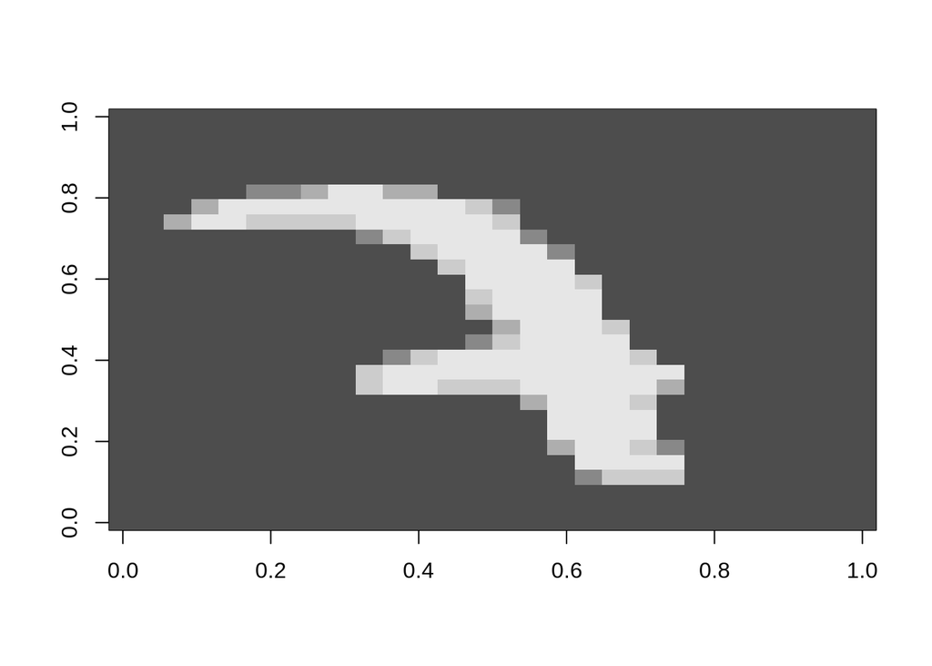

```r
index = 1:2060
wrong = index[pred_class[, 1]!=y_test]

# On choisit d'afficher les images d'index 145 et 223, que l'on récupère depuis la liste wrong qui représente la liste des index mal classés.
x_test[145,] %>% matrix(nrow = 28) %>% .[,28:1] %>% image(col = grey.colors(5))
```

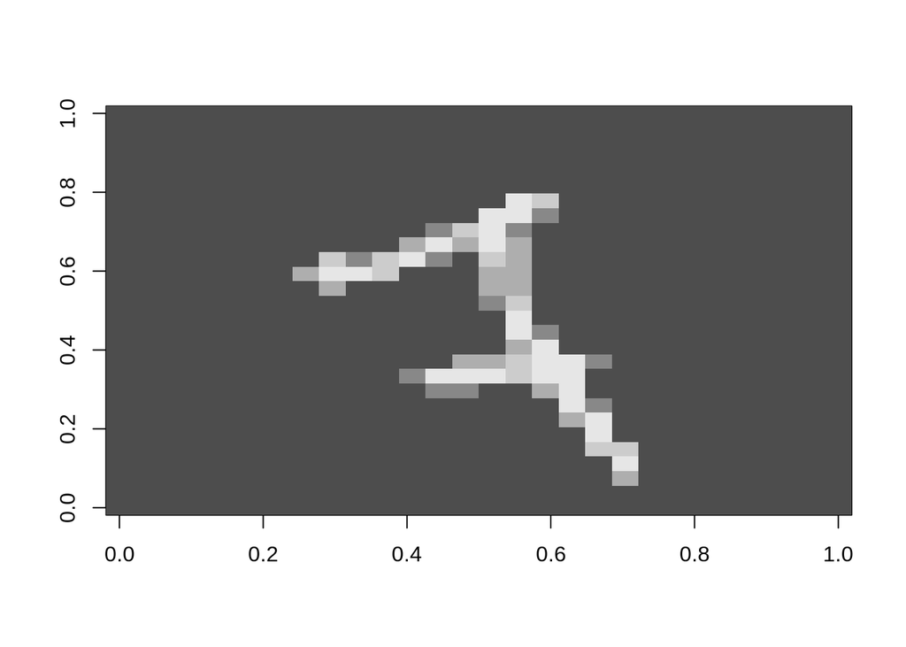

```r
x_test[223,] %>% matrix(nrow = 28) %>% .[,28:1] %>% image(col = grey.colors(5))
```

```r
# On affiche la liste des index mal classés ainsi que leurs probabilités de classement
pred <- predict_proba(model, x_test)[wrong]
data.frame(wrong, pred)
```

| wrong | pred |
| --- | --- |
| 72 | 9.999989e-01 |
| 145 | 2.621573e-03 |
| 223 | 4.926122e-02 |
| 264 | 4.623763e-06 |
| 382 | 1.000000e+00 |
| 405 | 1.988099e-02 |
| 557 | 4.669377e-02 |
| 786 | 2.031539e-03 |
| 887 | 9.807217e-01 |
| 1216 | 2.888858e-06 |

[output cut: 6 more lines]

## Défi MNIST

Pour les données de l’exercice précédent, répondre aux questions suivantes.

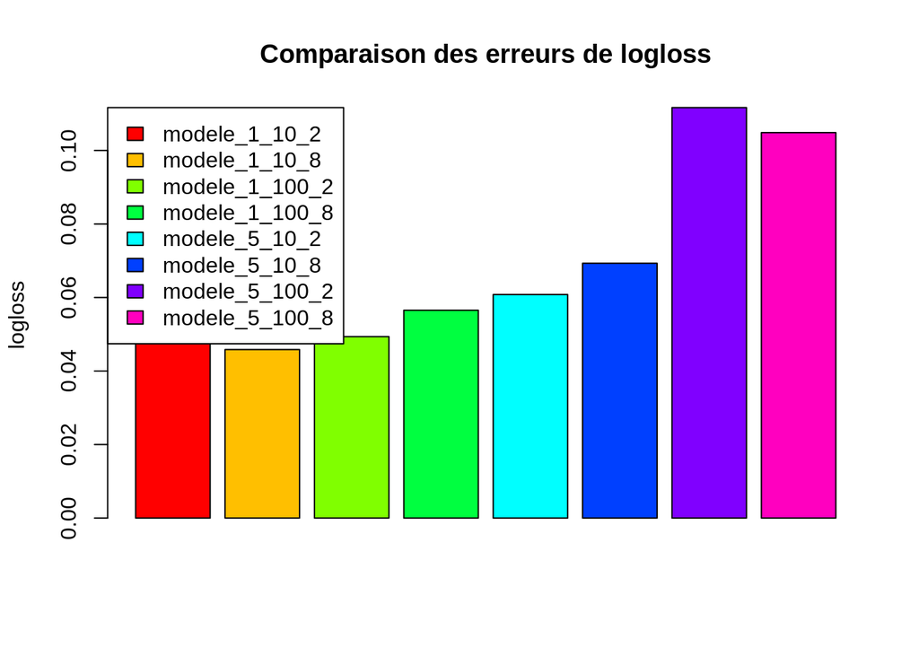

```r
set.seed(3)
nb_couches <-c(1, 5)
nb_neurones<-c(10, 100)
val_dropout<-c(0.2, 0.8)



create_model = function (nb_couches, nb_neurones, val_dropout){
  #Renvoie un modèle correspondant aux critères entrés en paramètres
  wanted_model <- keras_model_sequential()
  wanted_model %>%
    # Initialisation de la première couche avec fonction d'activation "relu" et 256 neurones.
    layer_dense(units = nb_neurones, activation = 'relu', input_shape = 784) %>%
    layer_dropout(rate = val_dropout)
  if(nb_couches != 1){
    for (i in 1:nb_couches){
      wanted_model %>%
      # Initialisation des couches suivantes
      layer_dense(units = nb_neurones, activation = 'relu') %>%
      layer_dropout(rate = val_dropout)
    }
  }
  wanted_model %>%
  # Initialisation de dernière couche
  layer_dense(units = 1, activation = 'sigmoid')
  return (wanted_model);
}


modele_1_10_2 <- create_model(1, 10, 2)
modele_1_10_8 <- create_model(1, 10, 8)
modele_1_100_2 <- create_model(1, 100, 2)
modele_1_100_8 <- create_model(1, 100, 8)
modele_5_10_2 <-  create_model(5, 10, 2)
modele_5_10_8 <-  create_model(5, 10, 8)
modele_5_100_2 <-  create_model(5,100, 2)
modele_5_100_8 <- create_model(5, 100, 8)

res_log_loss<-c()
res_acc<-c()
compteur = 1

model_instructions = function(model1){

      # Configuration du modèle pour l'apprentissage
      model1 %>% compile(
          loss = 'binary_crossentropy',
          optimizer = optimizer_rmsprop(lr = 0.001, rho = 0.9, decay = 0),
          metrics = c('accuracy')
      )

      # Entraînement du réseau
      history <- model1 %>% fit(
                              x_train,
                              y_train,
                              epochs = 20,
                              batch_size = 128,
                              validation_data = list(x_test, y_test))

      res <- c()
      res = model1 %>% evaluate(x_test, y_test)
      return(res)

}

res_log_loss[1] = model_instructions(modele_1_10_2)$loss
res_log_loss[2] = model_instructions(modele_1_10_8)$loss
res_log_loss[3] = model_instructions(modele_1_100_2)$loss
res_log_loss[4] = model_instructions(modele_1_100_8)$loss
res_log_loss[5] = model_instructions(modele_5_10_2)$loss
res_log_loss[6] = model_instructions(modele_5_10_8)$loss
res_log_loss[7] = model_instructions(modele_5_100_2)$loss
res_log_loss[8] = model_instructions(modele_5_100_8)$loss

res_acc[1] = model_instructions(modele_1_10_2)$acc
res_acc[2] = model_instructions(modele_1_10_8)$acc
res_acc[3] = model_instructions(modele_1_100_2)$acc
res_acc[4] = model_instructions(modele_1_100_8)$acc
res_acc[5] = model_instructions(modele_5_10_2)$acc
res_acc[6] = model_instructions(modele_5_10_8)$acc
res_acc[7] = model_instructions(modele_5_100_2)$acc
res_acc[8] = model_instructions(modele_5_100_8)$acc

names<-c("modele_1_10_2", "modele_1_10_8", "modele_1_100_2", "modele_1_100_8", "modele_5_10_2", "modele_5_10_8", "modele_5_100_2","modele_5_100_8")
data <- data.frame(names, res_log_loss, res_acc)
barplot(res_log_loss, main = "Comparaison des erreurs de logloss", ylab = "logloss", legend.text = data$names,  args.legend = list(x = "topleft"), col = rainbow((8)))
```

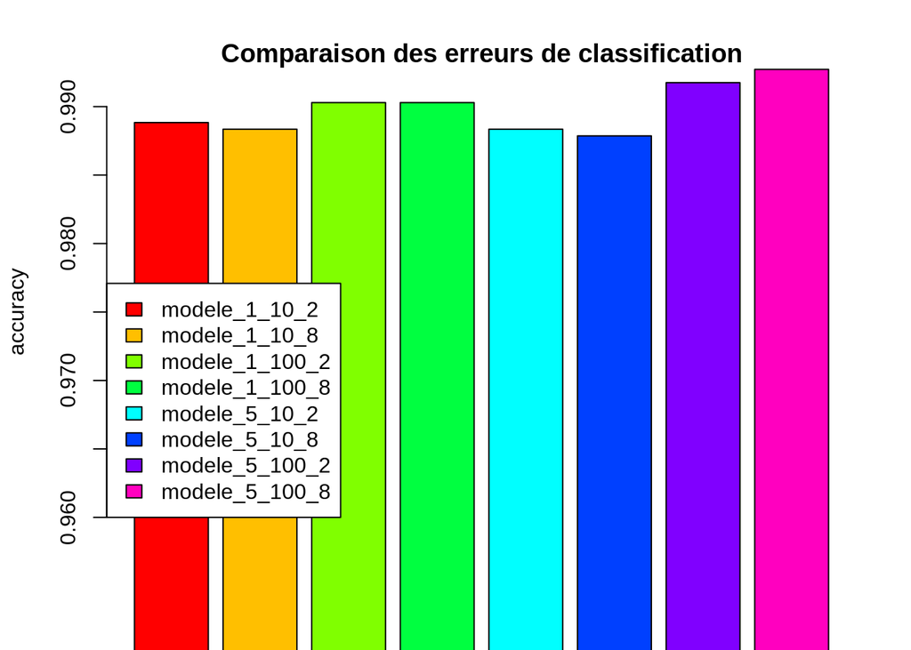

```r
barplot(res_acc, main = "Comparaison des erreurs de classification", ylab = "accuracy", ylim = c(0.96, 0.99), legend.text = data$names, args.legend = list(x = "bottomleft"), col = rainbow(8))
```

- Quel modèle de prédiction vous parait être le meilleur ?

Afin de faire notre choix, on essaie de trouver un modèle qui maximise l’accuracy et qui minimise la valeur du log loss, ainsi on choisi le modèle avec les paramètres 1, 100, 0.2.

- Donner la liste des chiffres mal classés et les probabilités de classement pour chacune des erreurs.

```r
probas<-c()
pred_class <- modele_1_100_2 %>% predict_classes(x_test)
wrong = index[pred_class[, 1]!=y_test]
for (i in 0:length(wrong)){
  probas[i] = predict_proba(modele_1_100_2, x_test)[wrong[i]]
}
data.frame(wrong, probas)
```

| wrong | probas |
| --- | --- |
| 72 | 9.999913e-01 |
| 145 | 3.733814e-04 |
| 223 | 6.491919e-02 |
| 264 | 2.092428e-11 |
| 375 | 3.348119e-01 |
| 382 | 1.000000e+00 |
| 405 | 6.685667e-02 |
| 429 | 5.961670e-01 |
| 557 | 2.497600e-01 |
| 786 | 2.764010e-06 |

[output cut: 10 more lines]